# HW-2-VOOR

## SI370 Winter 2018 -- Assignment 2

Due by: Jan 25 2:30pm.

Submission Instructions: Submit two files on Canvas:

1. A Jupyter Notebook file named HW-2-YOUR_UNIQUE_NAME.ipynb. Please observe the following requirements: This file should show all of the required work, including code, results, visualizations (if any), and necessary comments to your code. Irrelevant code and results should be deleted prior to submission.
2. An html file named HW-2-YOUR_UNIQUE_NAME.html showing the preview of the above IPython Notebook. To create this file, select File -> Download as HTML. We want this in case something breaks when we load your notebook. This will let us see what you saw when you were done.

**Please do NOT compress files. Before generating the html copy, please select Kernel -> Restart & Run All. This step guarantees all your output is consistent with your code.**

```python
# load a few libraries we'll need

%matplotlib inline
import pandas as pd
import random
import numpy as np
from random import sample
```

Next, setup your Jupyter Notebook display to use the same css files as we used in lab. Note: You do not need to attach the css files to your assignment. We will use the same css files in the folder of your assignment and your code should work.

```python
# make the Pandas tables a little more readable

from IPython.core.display import HTML
css = open('style-table.css').read() + open('style-notebook.css').read()
HTML('<style>{}</style>'.format(css))
```

## 1. More Names

In homework 1, we used the names dataset and learned how to do basic statistical analysis and report the Summary Statistics. In this assignment, we want to return to the names dataset, but this time do more interesting analysis on it. This will give you a bit more practice with series/dataframe selection.

Some of the following questions are similar to those in assignment 1, but now that you learned more about Pandas, you can answer them in a more efficient and easier way (e.g. by using groupby).

For this purpose, we should first load the names dataset again.

```python
df_1995 = pd.read_csv('names/yob1995.txt')
df_1995.head()
```

|  | name | gender | birth_count |
| --- | --- | --- | --- |
| 0 | Deziray | F | 8 |
| 1 | Nafis | M | 11 |
| 2 | Christan | F | 52 |
| 3 | Adeel | M | 8 |
| 4 | Nicolo | M | 30 |

Answer the following questions using proper Pandas operations. Both your code and results should be included in your submitted Jupyter Notebook (same below). All the questions in this section involve **df_1995** only.

### (a) What are the 10 most popular names in 1995? (3 points)

```python
df_1995_most_pop = df_1995.sort_values(by='birth_count', ascending=False)
df_1995_most_pop.head(10)
```

|  | name | gender | birth_count |
| --- | --- | --- | --- |
| 25236 | Michael | M | 41403 |
| 7446 | Matthew | M | 32874 |
| 24365 | Christopher | M | 32668 |
| 16553 | Jacob | M | 31122 |
| 16986 | Joshua | M | 30715 |
| 16349 | Nicholas | M | 29156 |
| 22273 | Tyler | M | 29153 |
| 13046 | Jessica | F | 27938 |
| 23033 | Brandon | M | 26901 |
| 3026 | Daniel | M | 26702 |

### (b) What are the 10 most popular boys' names in 1995? (3 points)

```python
df_1995_most_pop_boys = df_1995[(df_1995['gender']=='M')]
df_1995_most_pop_boys = df_1995_most_pop_boys.sort_values(by='birth_count', ascending=False)
df_1995_most_pop_boys.head(10)
```

|  | name | gender | birth_count |
| --- | --- | --- | --- |
| 25236 | Michael | M | 41403 |
| 7446 | Matthew | M | 32874 |
| 24365 | Christopher | M | 32668 |
| 16553 | Jacob | M | 31122 |
| 16986 | Joshua | M | 30715 |
| 16349 | Nicholas | M | 29156 |
| 22273 | Tyler | M | 29153 |
| 23033 | Brandon | M | 26901 |
| 3026 | Daniel | M | 26702 |
| 2393 | Austin | M | 25906 |

### (c) What are the 10 most popular girls' names in 1995?

```python
df_1995_most_pop_girls = df_1995[(df_1995['gender']=='F')]
df_1995_most_pop_girls = df_1995_most_pop_girls.sort_values(by='birth_count', ascending=False)
df_1995_most_pop_girls.head(10)
```

|  | name | gender | birth_count |
| --- | --- | --- | --- |
| 13046 | Jessica | F | 27938 |
| 23171 | Ashley | F | 26603 |
| 12165 | Emily | F | 24377 |
| 19798 | Samantha | F | 21646 |
| 15869 | Sarah | F | 21365 |
| 5046 | Taylor | F | 20424 |
| 17535 | Hannah | F | 17012 |
| 1811 | Brittany | F | 16477 |
| 13226 | Amanda | F | 16344 |
| 10566 | Elizabeth | F | 16183 |

### (d) What is the average birth_count of all names in 1995? (3 points)

```python
df_avg_birth_count = df_1995
df_avg_birth_count = df_avg_birth_count.mean()
df_avg_birth_count
```

```
birth_count    140.366526
dtype: float64
```

### (e) What is the median birth_count of boys' names in 1995? (2 points)

```python
df_1995_median_boys = df_1995[(df_1995['gender']=='M')]
df_1995_median_boys = df_1995_median_boys.median()
df_1995_median_boys
```

```
birth_count    11.0
dtype: float64
```

### (f) What is the maximum birth_count of girls' names in 1995? (2 points)

```python
df_1995_most_pop_girls = df_1995[(df_1995['gender']=='F')]
df_1995_most_pop_girls = df_1995_most_pop_girls.sort_values(by='birth_count', ascending=False)
df_1995_most_pop_girls.head(1)
```

|  | name | gender | birth_count |
| --- | --- | --- | --- |
| 13046 | Jessica | F | 27938 |

## The following questions involve **df_all** only.

```python
# we're going to move to the full dataset now
dfs = []
years = range(1880, 2015)
for y in years:
    df = pd.read_csv('names/yob%d.txt' % y)
    df['year'] = y
    dfs.append(df)
df_all = pd.concat(dfs, ignore_index=True)
df_all.head()
```

|  | name | gender | birth_count | year |
| --- | --- | --- | --- | --- |
| 0 | Simeon | M | 23 | 1880 |
| 1 | Raoul | M | 7 | 1880 |
| 2 | Lou | M | 14 | 1880 |
| 3 | Myra | F | 83 | 1880 |
| 4 | Alois | M | 10 | 1880 |

### (g) Plot the total #births for each year? (4 Points)

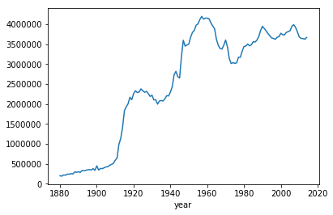

```python
df_all_birthsperyear = df_all.groupby('year')['birth_count'].sum().plot()
```

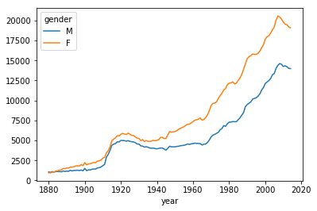

```python
dfbirths = df_all.pivot_table(values = 'name', index = ['year'],columns = ['gender'], aggfunc = 'count').fillna(0).sort_index()
dfbirths = dfbirths[['M','F']]
dfbirths.plot()
```

### (i) Which year has the maximum total number of births? (4 points)

```python
df1 = df_all.groupby('year')['birth_count'].sum()
df1_sorted = df1.sort_values(ascending=False)
df1_sorted.head(1)
```

```
year
1957    4200026
Name: birth_count, dtype: int64
```

### (j) Which year has the maximum total #births for boys? (4 points)

```python
df1_boys = df_all[(df_all['gender']=='M')]
df1_boys_grouped = df1_boys.groupby('year')['birth_count'].sum()
df1_boys_sorted = df1_boys_grouped.sort_values(ascending=False)
df1_boys_sorted.head(1)
```

```
year
1957    2155866
Name: birth_count, dtype: int64
```

### (k) Which year has the biggest absolute difference between #boys and #girls (i.e., abs(#boys-#girls))? (4 points)

```python
df2_boys = df_all[(df_all['gender']=='M')]
df2_girls = df_all[(df_all['gender']=='F')]
df2_girls_grouped = df2_girls.groupby('year')['birth_count'].sum()
df2_boys_grouped = df2_boys.groupby('year')['birth_count'].sum()
df_concat = pd.concat([df2_girls_grouped, df2_boys_grouped], axis=1).reset_index()
df_concat.columns = ['year', 'girls_birth_count', 'boys_birth_count']
df_concat['abs_diff'] = abs(df_concat['boys_birth_count']-df_concat['girls_birth_count'])
df_concat.sort_values(by='abs_diff', ascending=False).head(1)
```

|  | year | girls_birth_count | boys_birth_count | abs_diff |
| --- | --- | --- | --- | --- |
| 30 | 1910 | 396501 | 194218 | 202283 |

### (l) What are the 5 most popular boys' names in the 1990s (1990-1999)? (4 Points)

```python
df3 = df_all
df3['decade'] = df_all['year']// 10*10
df3 = df3[(df3['decade']==1990)&(df3['gender']=='M')]
df3 = df3.groupby('name')['birth_count'].sum()
df3.sort_values(ascending=False).head(5)
```

```
name
Michael        462278
Christopher    360176
Matthew        351580
Joshua         329082
Jacob          298249
Name: birth_count, dtype: int64
```

### (m) What are the 5 most popular girls' names in the 20th century (1901-2000)? (4 Points)

```python
df4 = df_all
#df4['century'] = df_all['year']// 100*100
df4 = df4[(df4['year']>=1901)&(df4['year']<=2000)&(df4['gender']=='F')]
df4 = df4.groupby('name')['birth_count'].sum()
df4.sort_values(ascending=False).head(5)
```

```
name
Mary        3822567
Patricia    1560081
Linda       1440703
Barbara     1422236
Jennifer    1398644
Name: birth_count, dtype: int64
```

### (n) Define the gender neutrality of a name as

```
                                min(#boys, #girls).
```

### In other words if the # of all the births for Jodan, 10000 were Male and, 5000 were Female, the "neutrality" score would be min(10000,5000) --> 5000

### What are the 15 names with the highest gender neutrality in the 1990s? (7 Points)

```python
df5_boys = df_all[(df_all['gender']=='M')&(df_all['year']>=1990)&(df_all['year']<=1999)]
df5_girls = df_all[(df_all['gender']=='F')&(df_all['year']>=1990)&(df_all['year']<=1999)]
df5_girls_grouped = df5_girls.groupby('name', as_index=False)['birth_count'].sum()
df5_boys_grouped = df5_boys.groupby('name', as_index=False)['birth_count'].sum()

df5_join = pd.merge(df5_girls_grouped, df5_boys_grouped, how='inner', on='name')

df5_join['neutrality']= df5_join[["birth_count_x", "birth_count_y"]].min(axis=1)
df5_join.sort_values(by='neutrality', ascending=False).head(15)
```

|  | name | birth_count_x | birth_count_y | neutrality |
| --- | --- | --- | --- | --- |
| 2126 | Jordan | 61742 | 144719 | 61742 |
| 4123 | Taylor | 169010 | 58392 | 58392 |
| 692 | Casey | 25895 | 29244 | 25895 |
| 215 | Angel | 19496 | 36980 | 19496 |
| 110 | Alexis | 131174 | 16253 | 16253 |
| 1297 | Dominique | 23642 | 10980 | 10980 |
| 3585 | Riley | 10230 | 18833 | 10230 |
| 3159 | Morgan | 91179 | 10098 | 10098 |
| 402 | Bailey | 31614 | 9924 | 9924 |
| 2048 | Jessie | 10137 | 9296 | 9296 |
| 979 | Dakota | 9149 | 46646 | 9149 |
| 1880 | Jamie | 41441 | 9085 | 9085 |
| 2809 | Logan | 8423 | 63557 | 8423 |
| 4312 | Tyler | 8416 | 262256 | 8416 |
| 332 | Ashton | 8689 | 7947 | 7947 |

### (o) Plot the proportion of the name "Mike" among all male names by year. (7 points)

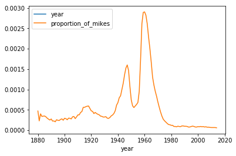

```python
df7 = df_all
df7_grouped = df7.groupby('year').agg({'birth_count':sum})
df7_mike = df7[(df7['name']=='Mike')].groupby('year').agg({'birth_count':sum})

df7_grouped['mikes']=df7_mike['birth_count']
df7_grouped['proportion_of_mikes'] = df7_grouped['mikes']/df7_grouped['birth_count']
df8 = df7_grouped.loc[:,['year','proportion_of_mikes']]
df8.plot()
```

## 2. Comic Characters

Download the "comic_characters.csv" dataset from Canvas . The original dataset is available at ["Comic Books Are Still Made By Men, For Men And About Men"] (http://fivethirtyeight.com/features/women-in-comic-books/).

The file contains the following columns:

publisher: Comic publisher: e.g., DC Comics or Marvel.  
name: The name of the character.  
identity: The identity statusof the character (Secret Identity, Public identity, [on marvel only: No Dual Identity]).  
align: If the character is Good, Bad or Neutral.  
eye: Eye color of the character.  
hair: Hair color of the character.  
sex: Sex of the character (e.g. Male, Female, etc.)  
alive: If the character is alive or deceased.  
appearances: The number of appareances of the character in comic books.  
first_appearance: The month and year of the character’s first appearance in a comic book, if available.  
month: The month of the character’s first appearance in a comic book, if available.  
year: The year of the character’s first appearance in a comic book, if available.  
date: The date of the character’s first appearance in a comic book, if available.

```python
comicCharacters = pd.DataFrame.from_csv('comic_characters.csv', index_col="id")
```

```python
comicCharacters.head()
```

| id | publisher | name | Identity | align | eye | hair | sex | alive | appearances | first_appearance | month | year | date |
| --- | --- | --- | --- | --- | --- | --- | --- | --- | --- | --- | --- | --- | --- |
| 1 | Marvel | Spider-Man (Peter Parker) | Secret Identity | Good Characters | Hazel Eyes | Brown Hair | Male Characters | Living Characters | 4043.0 | 1962, August | August | 1962.0 | 8/1/1962 |
| 2 | Marvel | Captain America (Steven Rogers) | Public Identity | Good Characters | Blue Eyes | White Hair | Male Characters | Living Characters | 3360.0 | 1941, March | March | 1941.0 | 3/1/1941 |
| 3 | Marvel | Wolverine (James \"Logan\" Howlett) | Public Identity | Neutral Characters | Blue Eyes | Black Hair | Male Characters | Living Characters | 3061.0 | 1974, October | October | 1974.0 | 10/1/1974 |
| 4 | Marvel | Iron Man (Anthony \"Tony\" Stark) | Public Identity | Good Characters | Blue Eyes | Black Hair | Male Characters | Living Characters | 2961.0 | 1963, March | March | 1963.0 | 3/1/1963 |
| 5 | Marvel | Thor (Thor Odinson) | No Dual Identity | Good Characters | Blue Eyes | Blond Hair | Male Characters | Living Characters | 2258.0 | 1950, November | November | 1950.0 | 11/1/1950 |

### (a) What is the total number of appearances of characters for each publisher? (Note: this is not asking for the number of unique characters but the number of appearances, each character *appears* multiple times, for example Thor appears 2258 times) (4 points)

```python
dfc1 = comicCharacters
dfc1=dfc1.groupby(['publisher'])['appearances'].sum()
dfc1
```

```
publisher
DC        154532.0
Marvel    260270.0
Name: appearances, dtype: float64
```

### (b) What is the total number of appearances of characters by each publisher in each year? Output a table. (4 points)

```python
dfc2 = comicCharacters
dfc2=dfc2.groupby(['year','publisher']).agg({'appearances':sum})
dfc2
```

| year | publisher | appearances |
| --- | --- | --- |
| 1935.0 | DC | 125.0 |
| 1936.0 | DC | 240.0 |
| 1937.0 | DC | 458.0 |
| 1938.0 | DC | 1639.0 |
| 1939.0 | DC | 4067.0 |
|  | Marvel | 1013.0 |
| 1940.0 | DC | 9123.0 |
|  | Marvel | 2160.0 |
| 1941.0 | DC | 6945.0 |
|  | Marvel | 5371.0 |
| 1942.0 | DC | 4068.0 |
|  | Marvel | 401.0 |
| 1943.0 | DC | 1475.0 |
|  | Marvel | 541.0 |
| 1944.0 | DC | 274.0 |
|  | Marvel | 960.0 |
| 1945.0 | DC | 259.0 |
|  | Marvel | 510.0 |
| 1946.0 | DC | 55.0 |
|  | Marvel | 274.0 |
| 1947.0 | DC | 933.0 |
|  | Marvel | 232.0 |
| 1948.0 | DC | 673.0 |
|  | Marvel | 1213.0 |
| 1949.0 | DC | 298.0 |
|  | Marvel | 1107.0 |
| 1950.0 | DC | 459.0 |
|  | Marvel | 2566.0 |
| 1951.0 | DC | 453.0 |
|  | Marvel | 576.0 |
| ... | ... | ... |
| 1999.0 | DC | 2285.0 |
|  | Marvel | 980.0 |
| 2000.0 | DC | 1350.0 |
|  | Marvel | 1578.0 |
| 2001.0 | DC | 994.0 |
|  | Marvel | 2280.0 |
| 2002.0 | DC | 886.0 |
|  | Marvel | 1962.0 |
| 2003.0 | DC | 1223.0 |
|  | Marvel | 3330.0 |
| 2004.0 | DC | 1614.0 |
|  | Marvel | 2835.0 |
| 2005.0 | DC | 1222.0 |
|  | Marvel | 3191.0 |
| 2006.0 | DC | 2914.0 |
|  | Marvel | 2434.0 |
| 2007.0 | DC | 1627.0 |
|  | Marvel | 1792.0 |
| 2008.0 | DC | 1813.0 |
|  | Marvel | 2429.0 |
| 2009.0 | DC | 1378.0 |
|  | Marvel | 1503.0 |
| 2010.0 | DC | 1008.0 |
|  | Marvel | 2233.0 |
| 2011.0 | DC | 483.0 |
|  | Marvel | 1890.0 |
| 2012.0 | DC | 17.0 |
|  | Marvel | 1072.0 |
| 2013.0 | DC | 1.0 |
|  | Marvel | 1177.0 |

154 rows × 1 columns

### (c) As you can see, it is difficult to figure out any trend in appearances of characters of each publisher in each year. Plot the time trend for each publisher separately and compare them. Plot a time series of appearances over time (one time series for each publisher). (7 points)

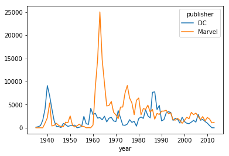

```python
dfc2.pivot_table(values = 'appearances', index = 'year', columns = 'publisher', fill_value=0).plot()
```

### (d) Which *hair* color has the maximum total appearances all over the years? (4 points)

```python
dfc3 = comicCharacters
dfc3 = dfc3.groupby('hair').agg({'appearances':sum})
dfc3.sort_values('appearances', ascending=False).head(1)
```

| hair | appearances |
| --- | --- |
| Black Hair | 110126.0 |

### (e) Which hair color has the biggest absolute difference of total appearances between males and females? Produce the output as a single row from a DataFrame. (5 points)

```python
dfc4 = comicCharacters
dfc5 = dfc4[(dfc4['sex']=='Male Characters')]
dfc6 = dfc4[(dfc4['sex']=='Female Characters')]
dfc5_grouped = dfc5.groupby('hair', as_index=False)['appearances'].sum()
dfc6_grouped = dfc6.groupby('hair', as_index=False)['appearances'].sum()

dfc_join = pd.merge(dfc5_grouped, dfc6_grouped, how='inner', on='hair')
dfc_join['abs_difference'] = abs(dfc_join['appearances_x']-dfc_join['appearances_y'])
dfc_join.sort_values('abs_difference', ascending=False).head(1)
```

|  | hair | appearances_x | appearances_y | abs_difference |
| --- | --- | --- | --- | --- |
| 5 | Brown Hair | 63204.0 | 15163.0 | 48041.0 |

### (f) Compare the total number of characters that are alive vs deceased of different sex throughout the years for the two publishers. (5 points)

Produce a single table that has this information (year/publisher/gender/living status) that shows the total number of appearances for those character types. Replace all the nulls with 0s.

```python
dfc7 = comicCharacters
dfc7.groupby(['publisher', 'sex', 'alive']).agg({'appearances':sum})
```

| publisher | sex | alive | appearances |
| --- | --- | --- | --- |
| DC | Female Characters | Deceased Characters | 7178.0 |
|  |  | Living Characters | 35085.0 |
|  | Genderless Characters | Deceased Characters | 50.0 |
|  |  | Living Characters | 194.0 |
|  | Male Characters | Deceased Characters | 26407.0 |
|  |  | Living Characters | 84498.0 |
|  | Transgender Characters | Deceased Characters | 4.0 |
| Marvel | Agender Characters | Deceased Characters | 48.0 |
|  |  | Living Characters | 778.0 |
|  | Female Characters | Deceased Characters | 10810.0 |
|  |  | Living Characters | 62195.0 |
|  | Genderfluid Characters | Living Characters | 565.0 |
|  | Male Characters | Deceased Characters | 32588.0 |
|  |  | Living Characters | 150013.0 |

# 3. Get creative

### What do you think is the most useful Pandas technique (or set of techniques) we have learned so far (in class, labs, or readings)? Come up with an interesting question and solve it using this technique. (10 points + 10 points of extra credit for outstanding solutions)

You can use any of the data sets we have used in class or, for additional points, use a different one.

This is an open ended question and a reasonable solution will earn full credit. Feel free to use any technique we have covered in class and any data set you find interesting.

```python
cast = pd.DataFrame.from_csv('cast.csv', index_col=None)
cast.head(15)
```

|  | title | year | name | type | character | n |
| --- | --- | --- | --- | --- | --- | --- |
| 0 | Closet Monster | 2015 | Buffy #1 | actor | Buffy 4 | NaN |
| 1 | Suuri illusioni | 1985 | Homo $ | actor | Guests | 22.0 |
| 2 | Battle of the Sexes | 2017 | $hutter | actor | Bobby Riggs Fan | 10.0 |
| 3 | Secret in Their Eyes | 2015 | $hutter | actor | 2002 Dodger Fan | NaN |
| 4 | Steve Jobs | 2015 | $hutter | actor | 1988 Opera House Patron | NaN |
| 5 | Straight Outta Compton | 2015 | $hutter | actor | Club Patron | NaN |
| 6 | Straight Outta Compton | 2015 | $hutter | actor | Dopeman | NaN |
| 7 | For Thy Love 2 | 2009 | Bee Moe $lim | actor | Thug 1 | NaN |
| 8 | Lapis, Ballpen at Diploma, a True to Life Journey | 2014 | Jori ' Danilo' Jurado Jr. | actor | Jaime (young) | 9.0 |
| 9 | Desire (III) | 2014 | Syaiful 'Ariffin | actor | Actor Playing Eteocles from 'Antigone' | NaN |
| 10 | When the Man Went South | 2014 | Taipaleti 'Atu'ake | actor | Two Palms - Ua'i Paame | 8.0 |
| 11 | Little Angel (Angelita) | 2015 | Michael 'babeepower' Viera | actor | Chico | 9.0 |
| 12 | Mixing Nia | 1998 | Michael 'babeepower' Viera | actor | Rapper | NaN |
| 13 | The Replacements | 2000 | Steven 'Bear'Boyd | actor | Defensive Tackle - Washington Sentinels | NaN |
| 14 | All Out Dysfunktion! | 2016 | Kirlew 'bliss' Vilbon | actor | Bliss | NaN |

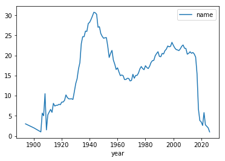

```python
# I like the different kinds of visualizations that are possible and the insight that they
# bring along with outside context.

# Plot the average number of actor roles per movie by year (what is the trend for size of cast?)

# I like this one because the graph is indicative of the rise of the 'American New Wave' in film
# and can be visualized in the dip in cast size between the 1960's and 1980's.

df8 = cast
df9 = df8.groupby(['year', 'title']).agg({'name':'count'})
df9.groupby('year').agg({'name':'mean'}).plot()
```